# Clase 4 Introducción Variables Aleatorias

05 July 2021

## PLAN DE LA CLASE

**1.- Introducción**

- Clasificación de variables aleatorias.
- Observar una variable cuantitativa continua.
- Predecir una variable cuantitativa continua.
- Identificar variables aleatorias discretas.
- Observar distribuciones de variables aleatorias discretas.

**2.- Práctica con R y Rstudio cloud**

- Observa y predice una variable aleatoria continua con distribución Normal.
- Observa y predice variables aleatorias discretas con distribución Bernoulli o Binomial.
- Elabora un reporte dinámico en formato pdf.

## TIPOS DE VARIABLES ALEATORIAS

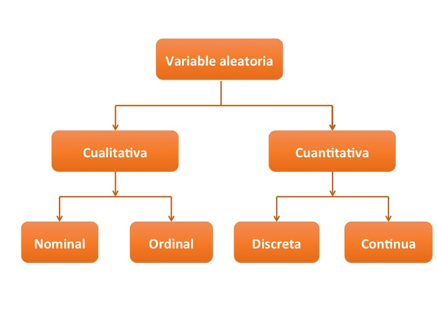

## CASOS ESPECIALES

**1.- Variable aleatoria binaria:** Posee dos resultados posibles; por ejemplo, éxito o fracaso, macho o hembra, sano o enfermo, (0,1).

**2.- Variable aleatoria dependiente del tiempo:**

**a) Discreta:** Días a la muerte de un organismo o fallo de un componente en un sistema en un tiempo *t*.

**b) Continua:** Señales de sensores ambientales o señales biométricos.

Algunas de estas variables se conocen como **series de tiempo** y en términos estrictos son más bien una *sucesión de variables aleatorias* a través del tiempo.

## VARIABLE ALEATORIA CUANTITATIVA CONTINUA

**Definición:** Puede tomar cualquier valor dentro de un intervalo (a,b), (a,Inf), (-Inf,b),(-Inf,Inf) y la probabilidad que toma cualquier punto es 0, debido a que existe un número infinito de posibilidades.

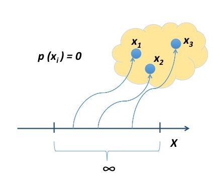

## OBSERVAR UNA VARIABLE CUANTITATIVA CONTINUA

Al observar con un histograma **hist()** notamos que:

1. La frecuencia o probabilidad en un intervalo es distinta de cero.
2. Cuando aumenta el **n** muestral se perfila una distribución llamada **normal**.

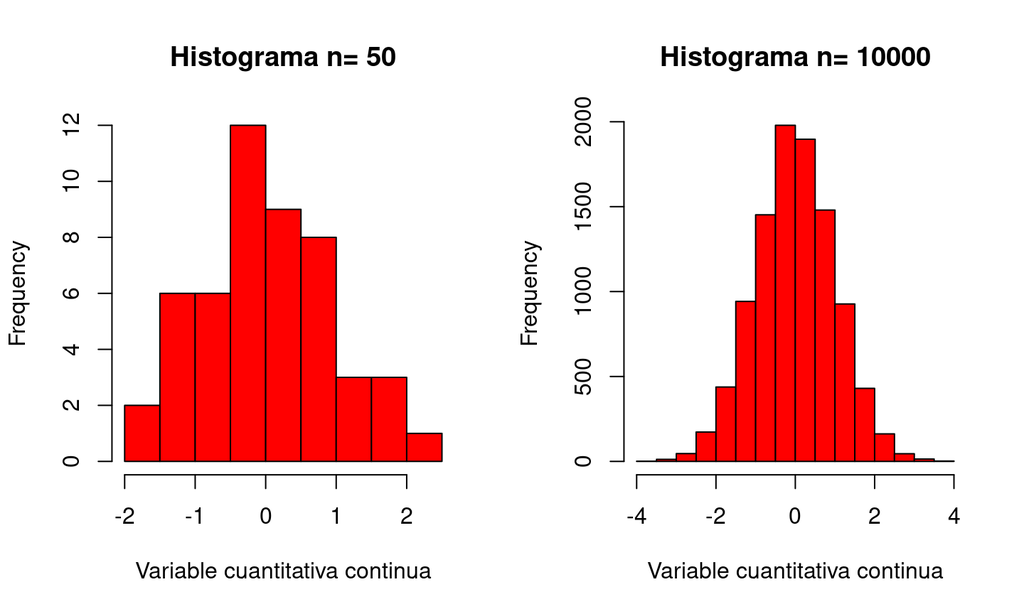

## PREDECIR UNA VARIABLE CUANTITATIVA CONTINUA

Podemos predecir la probabilidad de que la variable aleatoria tome un determinado valor usando la función de densidad empírica **density()**.

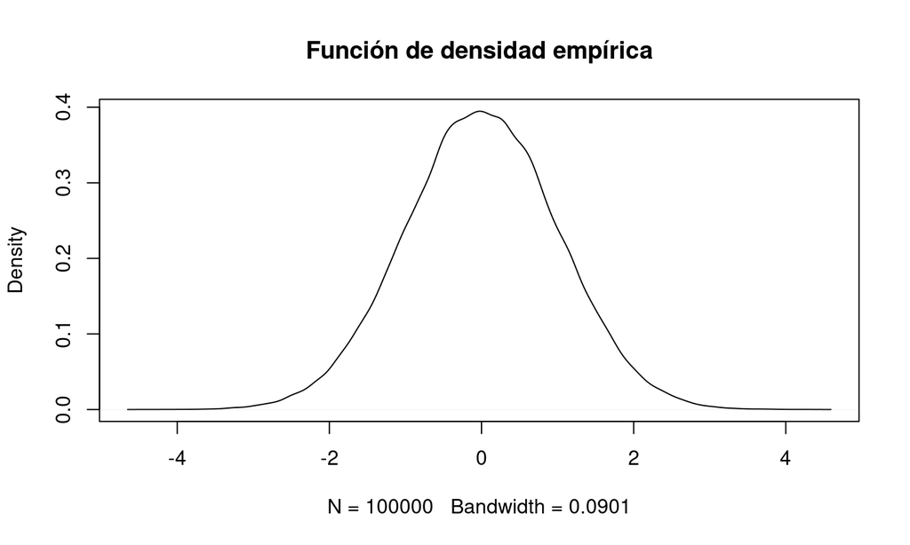

## PREDECIR VARIABLES CONTINUAS 2

Podemos predecir la probabilidad de que la variable aleatoria tome un valor menor o igual a un determinado valor, usando la función de distribución empírica acumulada **ecdf()**.

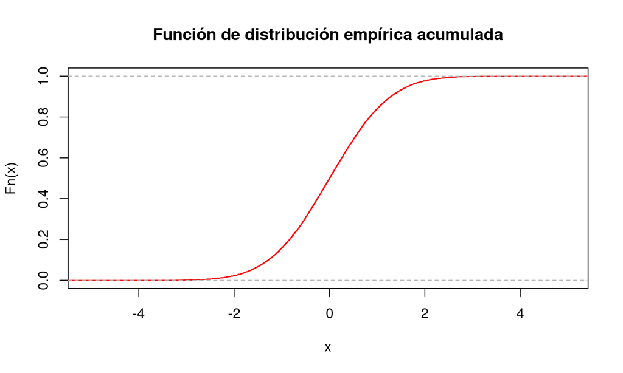

## OBSERVAR CON BOXPLOT

Las gráficas de cajas y bigotes (**boxplot()**) son muy adecuadas para observar variables aleatorias continuas.

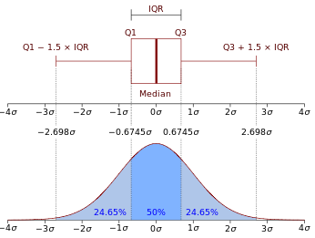

## VARIABLES ALEATORIAS DISCRETAS

Las variables aleatorias discretas son aquellas que presentan un número contable de valores; por ejemplo, **número de salmones que están en un estanque** (10, 50, 70, etc.), **número de parásitos presentes en tilapias** (1, 3, 5, 6, etc.), **días a la muerte durante el desafío** (1, 2, 3,…, 40).

## IMPORTANCIA DE IDENTIFICAR Y ANALIZAR VARIABLES ALEATORIAS DISCRETAS

- En gran parte, la *distribución de variables aleatorias discretas* puede ser **asimétrica a derecha o a izquierda**.
- Cuando las variables en estudio son conteos, proporciones o variables binarias (0 y 1); deben ser tratadas como **variables aleatorias discretas**.
- Según sea la variable aleatoria discreta, tendrá una función de distribución de probabilidad asociada **(Bernoulli, Binomial, Binomial Negativa, Poisson, entre otras)**.
- Es importante identificar la naturaleza que tiene nuestra variable en estudio, y así evitar errores en los análisis estadísticos que llevemos a cabo.

## EJEMPLOS DE VARIABLES ALEATORIAS DISCRETAS

- Presencia o ausencia de enfermedades en una tilapia (**Distribución Bernoulli**) (presencia:1 y ausencia:0).
- En una empresa de acuicultura se quiere hacer un estudio sobre el nivel de parásitos en la producción de salmones. Para ello, se tomó una muestra de **5** individuos cada día, repitiendo el experimento durante 600 días. De cada muestra se analizaron los peces determinando cuántos de ellos contenían parásitos. (**Distribución binomial**).

**X:** Número de individuos con parásitos. (X: 0,1,2,3,4,5)

- Número de salmones defectuosos observados en una cinta transportadora por minuto **(Distribución Poisson)**.

## EXPERIMENTO BERNOULLI

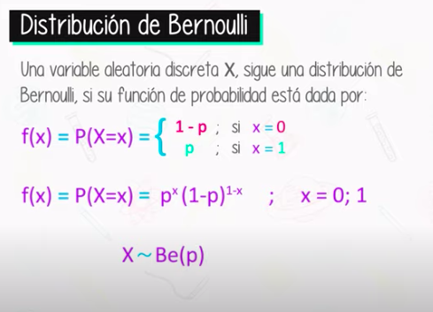

## **DISTRIBUCIÓN BERNOULLI**

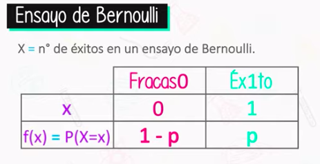

## **HISTOGRAMA Y FUNCIÓN DE DENSIDAD**

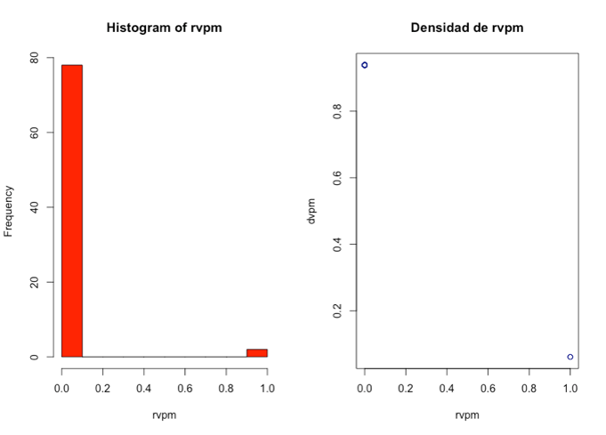

## **EXPERIMENTO BINOMIAL**

Es un experimento que debe cumplir las siguientes condiciones:

**1.** El experimento consta de una secuencia de **n** ensayos idénticos.

**2.** En cada ensayo hay dos resultados posibles. A uno de ellos se le llama **éxito** y al otro, **fracaso**.

**3.** La probabilidad de éxito es constante de un ensayo a otro, nunca cambia y se denota por **p**. Por ello, la probabilidad de fracaso será **1-p**.

**4.** Los ensayos son **independientes**, de modo que el resultado de cualquiera de ellos *no* influye en el resultado de cualquier otro ensayo.

## **VARIABLE ALEATORIA DISCRETA CON DISTRIBUCIÓN BINOMIAL NEGATIVA**

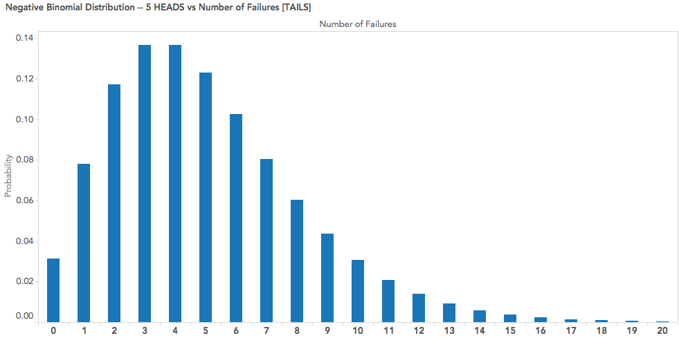

## **SIMULAR VARIABLE ALEATORIA DISCRETA CON DISTRIBUCIÓN BINOMIAL NEGATIVA**

La abundancia de parásitos como el piojo de mar es una variable discreta con distribución binomial negativa, esto significa que hay muchos peces con pocos parásitos (ej= 0 o 1) y poco con muchos parásitos.

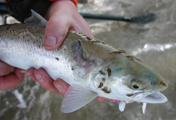

## **HISTOGRAMA Y BOXPLOT**

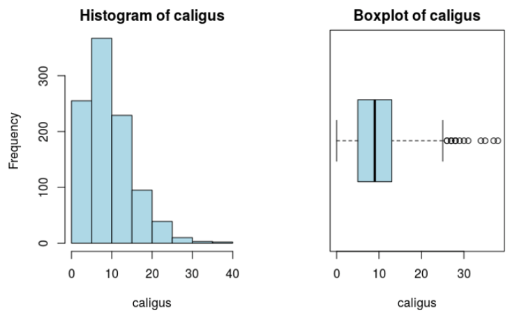

## PRÁCTICA ANÁLISIS DE DATOS

1.- Guía de trabajo Rmarkdown disponible en drive.  
**Clase 04-Introducción variables aleatoria**

2.- La tarea se realiza en Rstudio.cloud, proyecto.

## RESUMEN DE LA CLASE

- Identificamos y clasificamos variables aleatorias.
- Observamos una variable cuantitativa continua usando histogramas y boxplot.
- Predecimos el comportamiento de una variable cuantitativa continua usando funciones de densidad y de distribución acumulada.
- Estudiamos sobre variables aleatorias discretas y algunas distribuciones de probabilidad asociadas.